# NYPD Shooting Incident Data Analysis

SG

2026-02-15

## Introduction

Data sources (raw CSV):

- Incidents: https://raw.githubusercontent.com/SeanHGorman/DTSA5301/refs/heads/main/NYPD_Shootings_20260214.csv

> *Note: The publisher structure changed during the time this report was authored: offender and victim information was separated into additional files. This report focuses primarily on incident-level trends, and uses the incident table as the core dataset.*

## Setup and packages

```r
library(readr)
library(dplyr)
library(tidyr)
library(lubridate)
library(ggplot2)
library(janitor)
library(forcats)
library(sf)
library(ggspatial)
library(spdep)
library(units)
library(scales)
```

### Data Import

```r
inc_url <- "https://raw.githubusercontent.com/SeanHGorman/DTSA5301/refs/heads/main/NYPD_Shootings_20260214.csv"
off_url <- "https://raw.githubusercontent.com/SeanHGorman/DTSA5301/refs/heads/main/NYPD_Shooting_Offenders.csv"
vic_url <- "https://raw.githubusercontent.com/SeanHGorman/DTSA5301/refs/heads/main/NYPD_Shooting_Victims.csv"

inc_raw <- read_csv(inc_url) %>% clean_names()
off_raw <- read_csv(off_url) %>% clean_names()
vic_raw <- read_csv(vic_url) %>% clean_names()
```

### Initial Summary

```r
glimpse(inc_raw)
```

```
## Rows: 23,988
## Columns: 13
## $ incident_key       <dbl> 297623042, 73794477, 242784290, 24449553, 64318199,…
## $ occur_date         <chr> "12/06/2024", "07/21/2010", "03/28/2022", "09/23/20…
## $ occur_time         <time> 13:06:00, 01:32:00, 22:18:00, 00:02:00, 01:44:00, …
## $ boro               <chr> "MANHATTAN", "MANHATTAN", "MANHATTAN", "MANHATTAN",…
## $ loc_of_occur_desc  <chr> "OUTSIDE", "OUTSIDE", "OUTSIDE", "OUTSIDE", "OUTSID…
## $ precinct           <dbl> 1, 1, 5, 5, 5, 6, 7, 7, 7, 7, 7, 7, 9, 9, 9, 9, 10,…
## $ jurisdiction_code  <dbl> 0, 0, 0, 0, 2, 0, 0, 2, 2, 2, 0, 2, 0, 0, 0, 2, 2, …
## $ loc_classfctn_desc <chr> "STREET", "STREET", "STREET", "STREET", "HOUSING", …
## $ location_desc      <chr> NA, "BAR/NIGHT CLUB", "MULTI DWELL - APT BUILD", NA…
## $ x_coord_cd         <dbl> 983437, 982761, 984732, 986929, 986577, 982301, 987…
## $ y_coord_cd         <dbl> 201643, 204594, 200728, 202081, 200423, 204919, 200…
## $ latitude           <dbl> 40.72015, 40.72824, 40.71763, 40.72134, 40.71680, 4…
## $ longitude          <dbl> -74.00293, -74.00537, -73.99826, -73.99034, -73.991…
```

```r
summary(inc_raw)
```

```
##   incident_key        occur_date         occur_time           boro
##  Min.   :  9953245   Length:23988       Length:23988      Length:23988
##  1st Qu.: 70628818   Class :character   Class1:hms        Class :character
##  Median :137702226   Mode  :character   Class2:difftime   Mode  :character
##  Mean   :138977999                      Mode  :numeric
##  3rd Qu.:217025094
##  Max.   :318233895
##
##  loc_of_occur_desc     precinct      jurisdiction_code loc_classfctn_desc
##  Length:23988       Min.   :  1.00   Min.   :0.0000    Length:23988
##  Class :character   1st Qu.: 44.00   1st Qu.:0.0000    Class :character
##  Mode  :character   Median : 69.00   Median :0.0000    Mode  :character
##                     Mean   : 65.62   Mean   :0.3294
##                     3rd Qu.: 81.00   3rd Qu.:0.0000
##                     Max.   :123.00   Max.   :2.0000
##                                      NA's   :2
##  location_desc        x_coord_cd        y_coord_cd        latitude
##  Length:23988       Min.   : 914803   Min.   :125922   Min.   : 0.00
##  Class :character   1st Qu.:1000141   1st Qu.:182704   1st Qu.:40.67
##  Mode  :character   Median :1007715   Median :194257   Median :40.70
##                     Mean   :1009455   Mean   :208004   Mean   :40.67
##                     3rd Qu.:1016567   3rd Qu.:239414   3rd Qu.:40.82
##                     Max.   :1066815   Max.   :271127   Max.   :40.91
##                                                        NA's   :133
##    longitude
##  Min.   :-74.25
##  1st Qu.:-73.94
##  Median :-73.92
##  Mean   :-73.78
##  3rd Qu.:-73.88
##  Max.   :  0.00
##  NA's   :133
```

## Tidy and Transform Data

### Remove redundant/unused columns

This analysis uses latitude/longitude for mapping, so the alternative coordinate columns are removed. The incident key is a unique identifier and not needed for summary-level analysis.

```r
inc <- inc_raw %>%
  select(-incident_key, -x_coord_cd, -y_coord_cd)
```

### Convert types (dates + factors)

```r
inc <- inc %>%
  mutate(
    occur_date = mdy(occur_date),
    occur_year = year(occur_date),
    occur_month_num = month(occur_date),             # 1-12 for seasonality
    boro = as.factor(boro),
    precinct = as.factor(precinct)
  ) %>%
  arrange(occur_date)
```

### Missing data check (after handling)

```r
missing_after <- inc %>%
  summarise(across(everything(), ~sum(is.na(.)))) %>%
  pivot_longer(everything(), names_to = "column", values_to = "missing") %>%
  arrange(desc(missing))

missing_after
```

```
## # A tibble: 12 × 2
##    column             missing
##    <chr>                <int>
##  1 location_desc        14344
##  2 latitude               133
##  3 longitude              133
##  4 loc_classfctn_desc      32
##  5 jurisdiction_code        2
##  6 occur_date               0
##  7 occur_time               0
##  8 boro                     0
##  9 loc_of_occur_desc        0
## 10 precinct                 0
## 11 occur_year               0
## 12 occur_month_num          0
```

```r
summary(inc)
```

```
##    occur_date          occur_time                  boro      loc_of_occur_desc
##  Min.   :2006-01-01   Length:23988      BRONX        :6925   Length:23988
##  1st Qu.:2010-01-19   Class1:hms        BROOKLYN     :9677   Class :character
##  Median :2014-07-13   Class2:difftime   MANHATTAN    :3145   Mode  :character
##  Mean   :2015-02-26   Mode  :numeric    QUEENS       :3570
##  3rd Qu.:2020-08-24                     STATEN ISLAND: 671
##  Max.   :2025-12-31
##
##     precinct     jurisdiction_code loc_classfctn_desc location_desc
##  75     : 1372   Min.   :0.0000    Length:23988       Length:23988
##  73     : 1299   1st Qu.:0.0000    Class :character   Class :character
##  67     : 1094   Median :0.0000    Mode  :character   Mode  :character
##  79     :  867   Mean   :0.3294
##  44     :  864   3rd Qu.:0.0000
##  47     :  845   Max.   :2.0000
##  (Other):17647   NA's   :2
##     latitude       longitude        occur_year   occur_month_num
##  Min.   : 0.00   Min.   :-74.25   Min.   :2006   Min.   : 1.000
##  1st Qu.:40.67   1st Qu.:-73.94   1st Qu.:2010   1st Qu.: 4.000
##  Median :40.70   Median :-73.92   Median :2014   Median : 7.000
##  Mean   :40.67   Mean   :-73.78   Mean   :2015   Mean   : 6.799
##  3rd Qu.:40.82   3rd Qu.:-73.88   3rd Qu.:2020   3rd Qu.: 9.000
##  Max.   :40.91   Max.   :  0.00   Max.   :2025   Max.   :12.000
##  NA's   :133     NA's   :133
```

## Exploratory Analysis and Visualizations

### Visualization 1: Yearly Trend

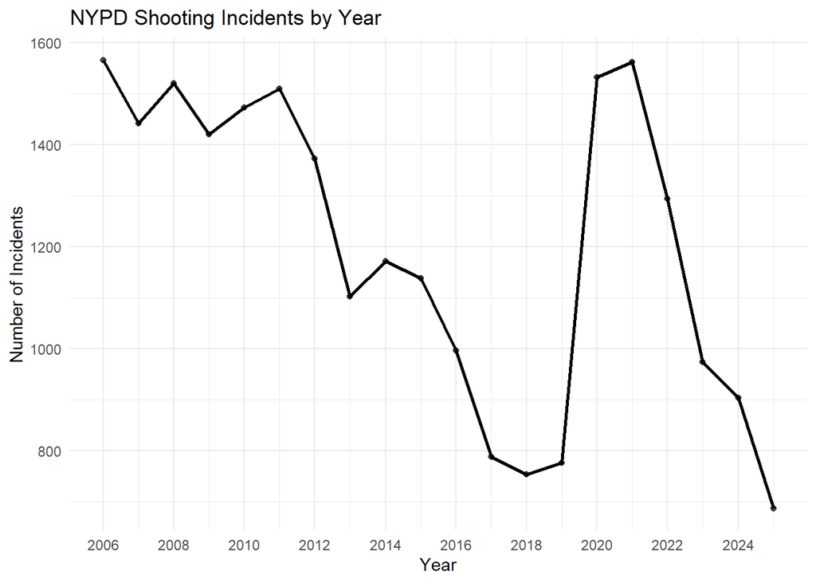

```r
year_counts <- inc %>% count(occur_year)

ggplot(year_counts, aes(x = occur_year, y = n)) +
  geom_line(linewidth = 1) +
  geom_point(size = 1.5, alpha = 0.7) +
  scale_x_continuous(breaks = seq(min(year_counts$occur_year),
                                  max(year_counts$occur_year),
                                  by = 2)) +
  labs(
    title = "NYPD Shooting Incidents by Year",
    x = "Year",
    y = "Number of Incidents"
  ) +
  theme_minimal()
```

**Interpretation**: Incidents generally decline from 2006 through 2019, then rise sharply around 2020–2021 and decline afterward. A reasonable follow-up question is whether the increase is concentrated in specific boroughs or precincts.

### Visualization 2: Seasonality (month-of-year)

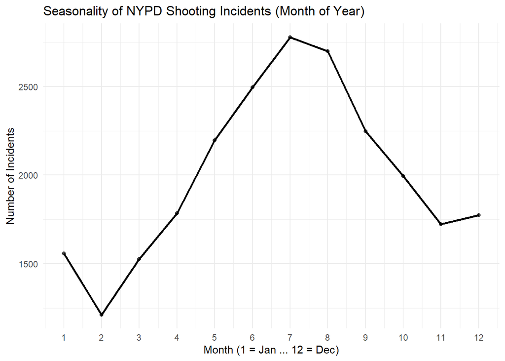

```r
monthly_counts <- inc %>% count(occur_month_num)

ggplot(monthly_counts, aes(x = occur_month_num, y = n)) +
  geom_line(linewidth = 1) +
  geom_point(size = 1.5, alpha = 0.7) +
  scale_x_continuous(breaks = 1:12) +
  labs(
    title = "Seasonality of NYPD Shooting Incidents (Month of Year)",
    x = "Month (1 = Jan ... 12 = Dec)",
    y = "Number of Incidents"
  ) +
  theme_minimal()
```

**Interpretation**: Incidents peak in warmer months (commonly around June–August). Follow-up question: is the seasonal pattern consistent across boroughs?

### Visualization 3: Borough Trends over time

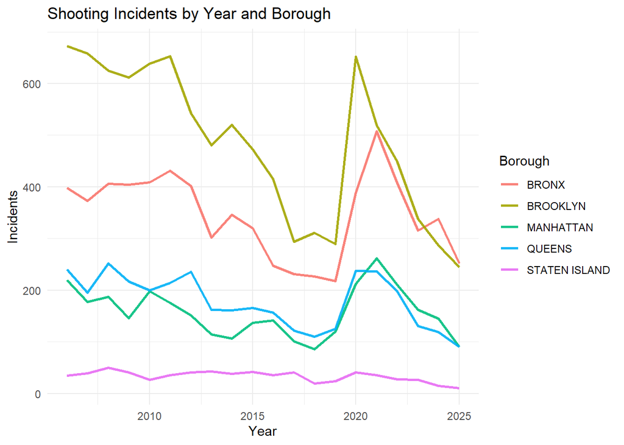

```r
boro_year <- inc %>% count(occur_year, boro)

ggplot(boro_year, aes(x = occur_year, y = n, group = boro, color = boro)) +
  geom_line(linewidth = 1, alpha = 0.9) +
  labs(
    title = "Shooting Incidents by Year and Borough",
    x = "Year",
    y = "Incidents",
    color = "Borough"
  ) +
  theme_minimal()
```

[figure not shown]

```r
boro_counts <- inc %>% count(boro, sort = TRUE)

ggplot(boro_counts, aes(x = reorder(boro, n), y = n, fill = boro)) +
  geom_col() +
  coord_flip() +
  labs(
    title = "Total Shooting Incidents by Borough (2006–2024)",
    x = "Borough",
    y = "Number of Incidents"
  ) +
  guides(fill = "none") +
  theme_minimal()
```

```r
inc_geo <- inc %>%
  filter(
    between(longitude, -74.3, -73.7),
    between(latitude, 40.5, 40.95)
  )
```

```r
inc %>%
  filter(occur_year %in% c(2019, 2020)) %>%
  count(occur_year, boro) %>%
  group_by(boro) %>%
  mutate(pct_change = (n - lag(n)) / lag(n) * 100)
```

```
## # A tibble: 10 × 4
## # Groups:   boro [5]
##    occur_year boro              n pct_change
##         <dbl> <fct>         <int>      <dbl>
##  1       2019 BRONX           218       NA
##  2       2019 BROOKLYN        290       NA
##  3       2019 MANHATTAN       120       NA
##  4       2019 QUEENS          125       NA
##  5       2019 STATEN ISLAND    24       NA
##  6       2020 BRONX           389       78.4
##  7       2020 BROOKLYN        652      125.
##  8       2020 MANHATTAN       212       76.7
##  9       2020 QUEENS          238       90.4
## 10       2020 STATEN ISLAND    41       70.8
```

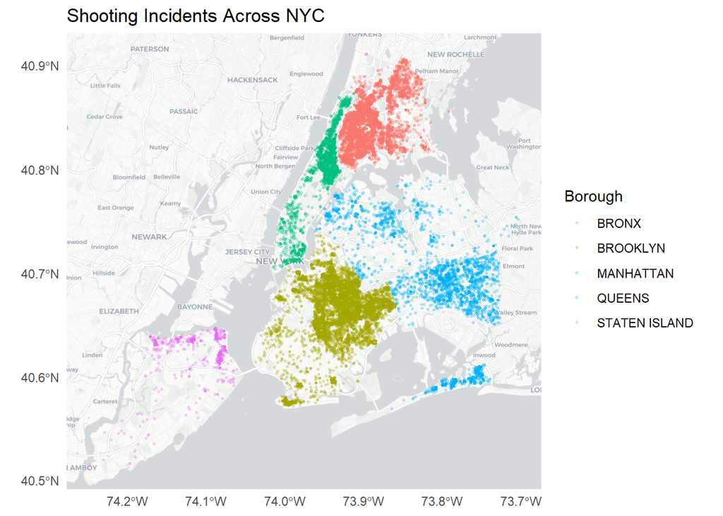

```r
inc_sf <- st_as_sf(inc_geo, coords = c("longitude", "latitude"), crs = 4326)
options(ggspatial.progress = FALSE)
ggplot() +
  annotation_map_tile(type = "cartolight", zoom = 11) +
  geom_sf(data = inc_sf, aes(color = boro), alpha = 0.25, size = 0.5) +
  labs(title = "Shooting Incidents Across NYC", color = "Borough") +
  theme_minimal()
```

**Interpretation**:While Brooklyn exhibits the highest number of incidents, it also shows the greatest year-to-year variability. However, this variation appears proportional to total incident volume rather than representing instability unique to the borough. Smaller boroughs such as Staten Island show lower variability, likely due to lower baseline counts.

```r
## From US Census Bureau (2020). 2020 Decennial Census (data.census.gov). Could not be directly queried in this report due to firewall issues, so I've hardcoded it here.

boro_pop <- tibble::tribble(
  ~boro,           ~population_2020,
  "BRONX",         1472654,
  "BROOKLYN",      2736074,
  "MANHATTAN",     1694251,
  "QUEENS",        2405464,
  "STATEN ISLAND",  495747
)

# Total incidents per borough
boro_totals <- inc %>%
  filter(!is.na(boro)) %>%
  count(boro, name = "incidents")

# Join population and compute per-capita rate
boro_rates <- boro_totals %>%
  left_join(boro_pop, by = "boro") %>%
  mutate(
    incidents_per_100k = incidents / population_2020 * 100000
  ) %>%
  arrange(desc(incidents_per_100k))

boro_rates
```

```
## # A tibble: 5 × 4
##   boro          incidents population_2020 incidents_per_100k
##   <chr>             <int>           <dbl>              <dbl>
## 1 BRONX              6925         1472654               470.
## 2 BROOKLYN           9677         2736074               354.
## 3 MANHATTAN          3145         1694251               186.
## 4 QUEENS             3570         2405464               148.
## 5 STATEN ISLAND       671          495747               135.
```

[figure not shown]

```r
ggplot(boro_rates, aes(x = reorder(boro, incidents_per_100k), y = incidents_per_100k, fill = boro)) +
  geom_col() +
  coord_flip() +
  labs(
    title = "Shooting Incidents per 100,000 Residents by Borough (2006–2024)",
    subtitle = "Normalization using approximate 2020 borough populations",
    x = "Borough",
    y = "Incidents per 100,000 residents"
  ) +
  guides(fill = "none") +
  theme_minimal()
```

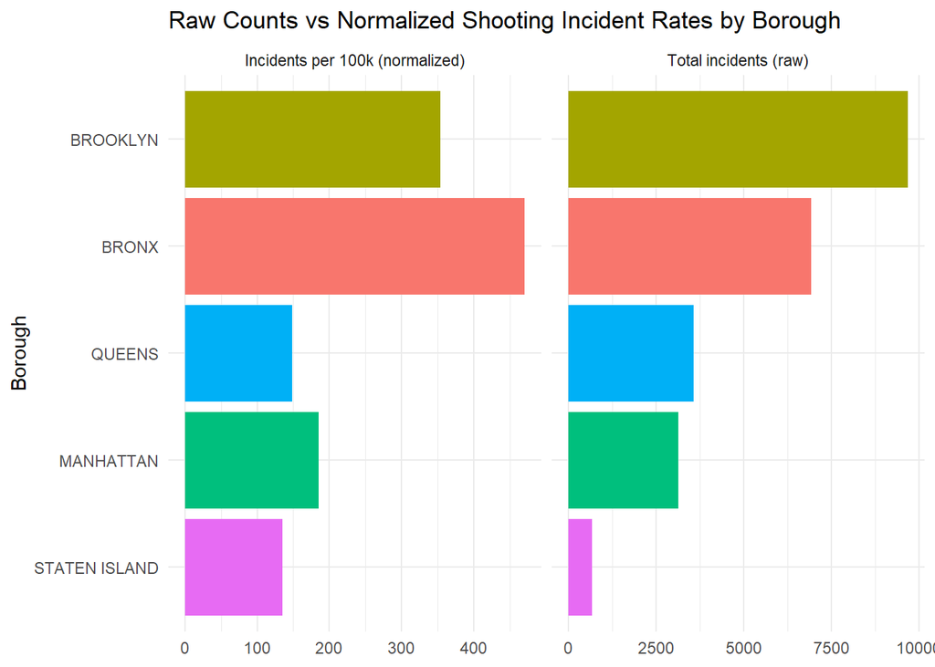

```r
boro_compare <- boro_rates %>%
  select(boro, incidents, incidents_per_100k) %>%
  pivot_longer(cols = c(incidents, incidents_per_100k),
               names_to = "metric",
               values_to = "value") %>%
  mutate(metric = recode(metric,
                         incidents = "Total incidents (raw)",
                         incidents_per_100k = "Incidents per 100k (normalized)"))

ggplot(boro_compare, aes(x = reorder(boro, value), y = value, fill = boro)) +
  geom_col() +
  coord_flip() +
  facet_wrap(~metric, scales = "free_x") +
  labs(
    title = "Raw Counts vs Normalized Shooting Incident Rates by Borough",
    x = "Borough",
    y = NULL
  ) +
  guides(fill = "none") +
  theme_minimal()
```

**Interpretation**: In raw totals, Brooklyn has the most shootings, which makes sense given its population. But when we adjust for population size, the Bronx actually has the highest rate per 100,000 residents. This shows why normalization matters — it helps distinguish between volume and relative concentration.

## Conclusion and Bias

### Conclusion

From 2006–2019, shooting incidents generally decreased, followed by a notable increase around 2020–2021 and a decline in later years. Incidents also show strong seasonality, with higher counts during warmer months. A borough-level breakdown helps identify whether the 2020–2021 increase was concentrated in particular areas, motivating further analysis at the precinct level.

### Sources of bias and limitations

Reporting/recording bias: incidents reflect what is reported and recorded by NYPD, not necessarily all incidents that occurred.

Geographic filtering bias: removing rows with missing or invalid coordinates improves mapping, but may disproportionately exclude certain records.

Time/coverage bias: the dataset structure changed over time (incidents split from victim/offender tables), which can affect what analyses are possible. As noted earlier, further analysis is recommended using these additional datasets

A potential personal bias is assuming that major external events (e.g., COVID-era disruption) caused changes seen in the trend. To mitigate this, this report limits claims to observed patterns in the data and frames external explanations as hypotheses that require additional evidence (e.g., comparing with policing policies, demographic data, or economic indicators).

#### Related Datasets

- Offenders: https://raw.githubusercontent.com/SeanHGorman/DTSA5301/refs/heads/main/NYPD_Shooting_Offenders.csv
- Victims: https://raw.githubusercontent.com/SeanHGorman/DTSA5301/refs/heads/main/NYPD_Shooting_Victims.csv